# Modern Data Mining, HW 1

Group Member 1

Group Member 2

Group Member 3

Due: 11:59PM, Jan. 30th, 2021

# 1 Overview

This is a fast-paced course that covers a lot of material. There will be a large amount of references. You may need to do your own research to fill in the gaps in between lectures and homework/projects. It is impossible to learn data science without getting your hands dirty. Please budget your time evenly. Last-minute work ethic will not work for this course.

Homework in this course is different from your usual homework assignment as a typical student. Most of the time, they are built over real case studies. While you will be applying methods covered in lectures, you will also find that extra teaching materials appear here. The focus will be always on the goals of the study, the usefulness of the data gathered, and the limitations in any conclusions you may draw. Always try to challenge your data analysis in a critical way. Frequently, there are no unique solutions.

Case studies in each homework can be listed as your data science projects (e.g. on your CV) where you see fit.

## 1.1 Objectives

- Get familiar with `R-studio` and `RMarkdown`
- Hands-on R
- Learn data science essentials
  - gather data
  - clean data
  - summarize data
  - display data
  - conclusion
- Packages
  - `dplyr`
  - `ggplot`

## 1.2 Instructions

- **Homework assignments can be done in a group consisting of up to three members**. Please find your group members as soon as possible and register your group on our Canvas site.
- **All work submitted should be completed in the R Markdown format.** You can find a cheat sheet for R Markdown [here](https://github.com/rstudio/cheatsheets/raw/master/rmarkdown-2.0.pdf). For those who have never used it before, we urge you to start this homework as soon as possible.
- **Submit the following files, one submission for each group:** (1) Rmd file, (2) a compiled PDF or HTML version, and (3) all necessary data files if different from our source data. You may directly edit this .rmd file to add your answers. If you intend to work on the problems separately within your group, compile your answers into one Rmd file before submitting. We encourage that you at least attempt each problem by yourself before working with your teammates. Additionally, ensure that you can ‘knit’ or compile your Rmd file. It is also likely that you need to configure Rstudio to properly convert files to PDF. [**These instructions**](http://kbroman.org/knitr_knutshell/pages/latex.html#converting-knitrlatex-to-pdf) might be helpful.
- In general, be as concise as possible while giving a fully complete answer to each question. All necessary datasets are available in this homework folder on Canvas. Make sure to document your code with comments (written on separate lines in a code chunk using a hashtag `#` before the comment) so the teaching fellows can follow along. R Markdown is particularly useful because it follows a ‘stream of consciousness’ approach: as you write code in a code chunk, make sure to explain what you are doing outside of the chunk.
- A few good or solicited submissions will be used as sample solutions. When those are released, make sure to compare your answers and understand the solutions.

## 1.3 Review materials

- Study Advanced R Tutorial (to include `dplyr` and `ggplot`)
- Study lecture 1: Data Acquisition and EDA

# 2 Case study 1: Audience Size

How successful is the Wharton Talk Show [Business Radio Powered by the Wharton School](https://businessradio.wharton.upenn.edu/)

**Background:** Have you ever listened to [SiriusXM](https://www.siriusxm.com/)? Do you know there is a **Talk Show** run by Wharton professors in Sirius Radio? Wharton launched a talk show called [Business Radio Powered by the Wharton School](https://businessradio.wharton.upenn.edu/) through the Sirius Radio station in January of 2014. Within a short period of time the general reaction seemed to be overwhelmingly positive. To find out the audience size for the show, we designed a survey and collected a data set via MTURK in May of 2014. Our goal was to **estimate the audience size**. There were 51.6 million Sirius Radio listeners then. One approach is to estimate the proportion of the Wharton listeners to that of the Sirius listeners, $p$, so that we will come up with an audience size estimate of approximately 51.6 million times $p$.

To do so, we launched a survey via Amazon Mechanical Turk ([MTurk](https://www.mturk.com/)) on May 24, 2014 at an offered price of $0.10 for each answered survey. We set it to be run for 6 days with a target maximum sample size of 2000 as our goal. Most of the observations came in within the first two days. The main questions of interest are “Have you ever listened to Sirius Radio” and “Have you ever listened to Sirius Business Radio by Wharton?”. A few demographic features used as control variables were also collected; these include Gender, Age and Household Income.

We requested that only people in United States answer the questions. Each person can only fill in the questionnaire once to avoid duplicates. Aside from these restrictions, we opened the survey to everyone in MTurk with a hope that the sample would be more randomly chosen.

The raw data is stored as `Survey_results_final.csv` on Canvas.

## 2.1 Data preparation

1. We need to clean and select only the variables of interest.

Select only the variables Age, Gender, Education Level, Household Income in 2013, Sirius Listener?, Wharton Listener? and Time used to finish the survey.

Change the variable names to be “age”, “gender”, “education”, “income”, “sirius”, “wharton”, “worktime”.

2. Handle missing/wrongly filled values of the selected variables

As in real world data with user input, the data is incomplete, with missing values, and has incorrect responses. There is no general rule for dealing with these problems beyond “use common sense.” In whatever case, explain what the problems were and how you addressed them. Be sure to explain your rationale for your chosen methods of handling issues with the data. Do not use Excel for this, however tempting it might be.

Tip: Reflect on the reasons for which data could be wrong or missing. How would you address each case? For this homework, if you are trying to predict missing values with regression, you are definitely overthinking. Keep it simple.

3. Brief summary

Write a brief report to summarize all the variables collected. Include both summary statistics (including sample size) and graphical displays such as histograms or bar charts where appropriate. Comment on what you have found from this sample. (For example - it’s very interesting to think about why would one work for a job that pays only 10cents/each survey? Who are those survey workers? The answer may be interesting even if it may not directly relate to our goal.)

## 2.2 Sample properties

The population from which the sample is drawn determines where the results of our analysis can be applied or generalized. We include some basic demographic information for the purpose of identifying sample bias, if any exists. Combine our data and the general population distribution in age, gender and income to try to characterize our sample on hand.

1. Does this sample appear to be a random sample from the general population of the USA?
2. Does this sample appear to be a random sample from the MTURK population?

Note: You can not provide evidence by simply looking at our data here. For example, you need to find distribution of education in our age group in US to see if the two groups match in distribution. You may need to gather some background information about the MTURK population to have a slight sense if this particular sample seem to a random sample from there… Please do not spend too much time gathering evidence.

## 2.3 Final estimate

Give a final estimate of the Wharton audience size in January 2014. Assume that the sample is a random sample of the MTURK population, and that the proportion of Wharton listeners vs. Sirius listeners in the general population is the same as that in the MTURK population. Write a brief executive summary to summarize your findings and how you came to that conclusion.

To be specific, you should include:

1. Goal of the study
2. Method used: data gathering, estimation methods
3. Findings
4. Limitations of the study.

## 2.4 New task

Now suppose you are asked to design a study to estimate the audience size of Wharton Business Radio Show as of today: You are given a budget of $1000. You need to present your findings in two months.

Write a proposal for this study which includes:

1. Method proposed to estimate the audience size.
2. What data should be collected and where it should be sourced from. Please fill in the google form to list your platform where surveys will be launched and collected [HERE](https://forms.gle/8SmjFQ1tpqr6c4sa8)

A good proposal will give an accurate estimation with the least amount of money used.

# 3 Case study 2: Women in Science

Are women underrepresented in science in general? How does gender relate to the type of educational degree pursued? Does the number of higher degrees increase over the years? In an attempt to answer these questions, we assembled a data set (`WomenData_06_16.xlsx`) from [NSF](https://ncses.nsf.gov/pubs/nsf19304/digest/field-of-degree-women) about various degrees granted in the U.S. from 2006 to 2016. It contains the following variables: Field (Non-science-engineering (`Non-S&E`) and sciences (`Computer sciences`, `Mathematics and statistics`, etc.)), Degree (`BS`, `MS`, `PhD`), Sex (`M`, `F`), Number of degrees granted, and Year.

Our goal is to answer the above questions only through EDA (Exploratory Data Analyses) without formal testing. We have provided sample R-codes in the appendix to help you if needed.

## 3.1 Data preparation

1. Understand and clean the data

Notice the data came in as an Excel file. We need to use the package `readxl` and the function `read_excel()` to read the data `WomenData_06_16.xlsx` into R.

```r
# i. Read the data into R
w_df <- read_excel("data/WomenData_06_16.xlsx")

# ii. Clean the names of each variables.
# Change variable names to  `Field`,`Degree`, `Sex`, `Year` and `Number`.
w_df <- w_df %>% rename("Field" = "Field and sex",
                        "Number" = "Degrees Awarded")

# iii. Set the variable natures properly
str(w_df)

# renaming a field name to shorter name
w_df[w_df$Field == "Earth, atmospheric, and ocean sciences", "Field"] <- "Environmental"
w_df[w_df$Field == "Mathematics and statistics", "Field"] <- "Math & Stats"
w_df[w_df$Field == "Agricultural sciences", "Field"] <- "Agriculture"
w_df[w_df$Field == "Biological sciences", "Field"] <- "Biology"
w_df[w_df$Field == "Social sciences", "Field"] <- "Sociology"
w_df[w_df$Field == "Computer sciences", "Field"] <- "Computer"
w_df[w_df$Field == "Physical sciences", "Field"] <- "Physics"

# Changing categorical variables from character to factor type
w_df %<>% mutate(Field = as.factor(Field),
         Degree = as.factor(Degree),
         Sex = as.factor(Sex))

# iv. Any missing values?
summary(w_df)
# no missing values.

# count the number of fields
length(unique(w_df$Field))

# count the number of degrees
length(unique(w_df$Degree))

# count the number of years reported
max(w_df$Year) - min(w_df$Year)
```

```r
# preparing html output table
kbl(summary(w_df)) %>%
  kable_styling(bootstrap_options = "striped", full_width = F, position = "left")
```

|  | Field | Degree | Sex | Year | Number |
| --- | --- | --- | --- | --- | --- |
|  | Agriculture : 66 | BS :220 | Female:330 | Min. :2006 | Min. : 218 |
|  | Biology : 66 | MS :220 | Male :330 | 1st Qu.:2008 | 1st Qu.: 2118 |
|  | Computer : 66 | PhD:220 | NA | Median :2011 | Median : 6020 |
|  | Engineering : 66 | NA | NA | Mean :2011 | Mean : 41717 |
|  | Environmental: 66 | NA | NA | 3rd Qu.:2014 | 3rd Qu.: 18127 |
|  | Math & Stats : 66 | NA | NA | Max. :2016 | Max. :781474 |
|  | (Other) :264 | NA | NA | NA | NA |

2. Write a summary describing the data set provided here.
1. How many fields are there in this data?

There are 10 different fields of study in this dataset.

2. What are the degree types?

There are 3 degree types.

3. How many year’s statistics are being reported here?

Is there evidence that more males are in science-related fields vs `Non-S&E`? Provide summary statistics and a plot which shows the number of people by gender and by field. Write a brief summary to describe your findings.

### 3.2.1 Summary statistics by field and gender

```r
# summarizing by field and sex
agg <- w_df %>%
  group_by(Field, Sex) %>%
  summarise(
    Total_Number = sum(Number)
    )

# preparing html output table
kbl(agg) %>%
  kable_paper() %>%
    scroll_box(height = "300px")
```

| Field | Sex | Total_Number |
| --- | --- | --- |
| Agriculture | Female | 172852 |
| Agriculture | Male | 152956 |
| Biology | Female | 745384 |
| Biology | Male | 516556 |
| Computer | Female | 171808 |
| Computer | Male | 626248 |
| Engineering | Female | 301426 |
| Engineering | Male | 1147112 |
| Environmental | Female | 36076 |
| Environmental | Male | 53118 |
| Math & Stats | Female | 125083 |
| Math & Stats | Male | 173641 |
| Non-S&E | Female | 11916324 |
| Non-S&E | Male | 7356720 |
| Physics | Female | 120797 |
| Physics | Male | 194365 |
| Psychology | Female | 1109902 |
| Psychology | Male | 326865 |
| Sociology | Female | 1244592 |
| Sociology | Male | 1041377 |

### 3.2.2 Plots by field and gender

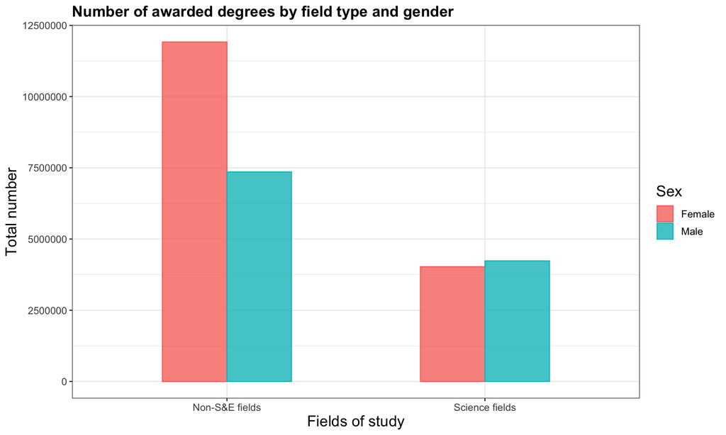

```r
# disabling scientific notation for plotting
options(scipen = 999)

# creating new science vs non-science fields variable
w_df$Field_type <- ifelse(w_df$Field == "Non-S&E", c("Non-S&E fields"), c("Science fields"))

# getting total number of degrees per field type
w_df %>% group_by(Field_type, Sex) %>%
  summarise(total_number = sum(Number)) %>%
  # bar plots per gender and field type (while sorting data by max number in males per field)
  ggplot(aes(x = Field_type, y = total_number, fill = Sex, colour = Sex)) +
    geom_bar(stat = "identity", position = "dodge", alpha = 0.8, width = 0.5) +
    theme_bw() +
    labs(x="Fields of study", y = "Total number") +
    ggtitle("Number of awarded degrees by field type and gender") +
    theme(plot.title = element_text(face="bold", size = 15)) +
    theme(legend.text = element_text(size = 10),
          legend.title = element_text(size = 15),
          axis.title = element_text(size = 15),
          axis.text.x = element_text(size = 10),
          axis.text.y = element_text(size = 10))
```

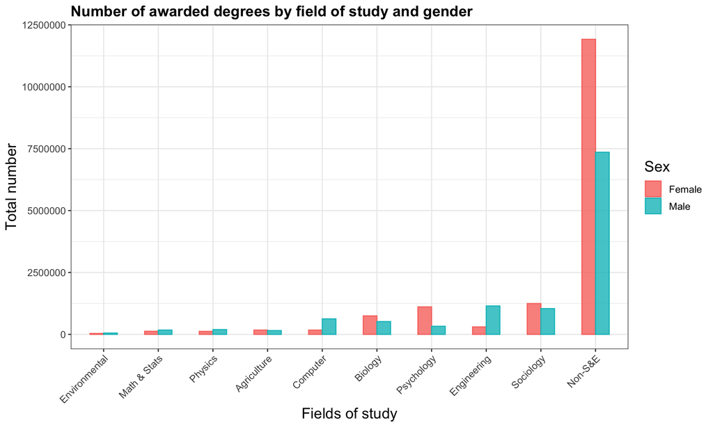

```r
# getting total number of degrees per field
w_df %>% group_by(Field, Sex) %>%
  summarise(total_number = sum(Number)) %>%
  # bar plots per gender and field (while sorting data by max number in males per field)
  ggplot(aes(x = forcats::fct_reorder(Field, total_number), y = total_number, fill = Sex, colour = Sex)) +
    geom_bar(stat = "identity", position = "dodge", alpha = 0.8, width = 0.5) +
    theme_bw() +
    labs(x="Fields of study", y = "Total number") +
    ggtitle("Number of awarded degrees by field of study and gender") +
    theme(plot.title = element_text(face="bold", size = 15)) +
    theme(legend.text = element_text(size = 10),
          legend.title = element_text(size = 15),
          axis.title = element_text(size = 15),
          axis.text.x = element_text(size = 10, angle = 45, hjust = 1),
          axis.text.y = element_text(size = 10))
```

Based on the above evidence, it appears that the number of men in `Science fields` is comparable to the number of women. This constrasts with `Non-S&E` fields, which comprises a much larger number of women. This finding should however be nuanced by the fact that subfields within `Science fields` show very different male/female proportions. For instance, `Biological Sciences` and `Psychology` have a majority of female students, while `Computer sciences` and `Engineering` have a majority of male students.

An additional observation is that the number of students in `Non-S&E` fields overall is much larger than in `Science fields`. To further improve the visualization of gender proportions, we created a graph displaying the propotions of each gender (rather than total number) in different fields.

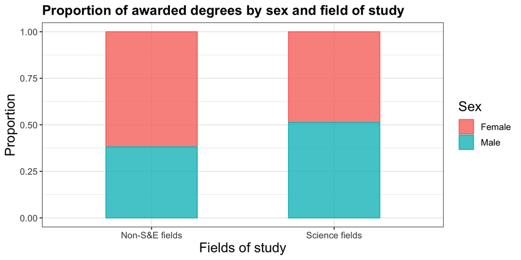

```r
# getting total number of degrees per field type
w_df %>% group_by(Field_type, Sex) %>%
  summarise(total_number = sum(Number)) %>%
  # bar plots per gender and field type (while sorting data by max number in males per field)
  ggplot(aes(x = Field_type, y = total_number, fill = Sex, colour = Sex)) +
    geom_bar(stat = "identity", position = "fill", alpha = 0.8, width = 0.5) +
    theme_bw() +
    labs(x="Fields of study", y = "Proportion") +
    ggtitle("Proportion of awarded degrees by sex and field of study") +
    theme(plot.title = element_text(face="bold", size = 15)) +
    theme(legend.text = element_text(size = 10),
          legend.title = element_text(size = 15),
          axis.title = element_text(size = 15),
          axis.text.x = element_text(size = 10),
          axis.text.y = element_text(size = 10))
```

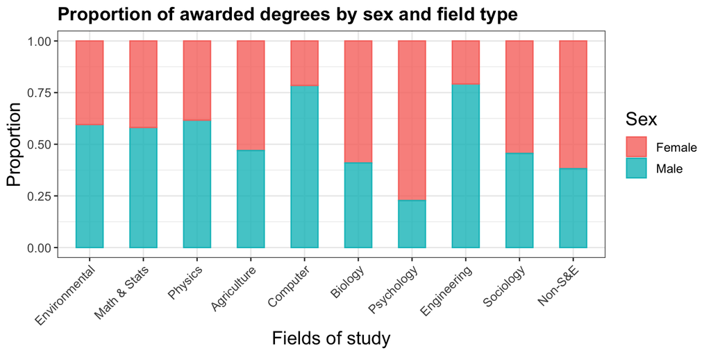

```r
# getting total number of degrees per field
w_df %>% group_by(Field, Sex) %>%
  summarise(total_number = sum(Number)) %>%
  arrange(desc(total_number))  %>%
  ggplot(aes(x = fct_reorder(Field, total_number), y = total_number, fill = Sex, colour = Sex)) +
    geom_bar(stat = "identity", position = "fill", alpha = 0.8, width = 0.5) +
    theme_bw() +
    labs(x="Fields of study", y = "Proportion") +
    ggtitle("Proportion of awarded degrees by sex and field type") +
    theme(plot.title = element_text(face="bold", size = 15)) +
    theme(legend.text = element_text(size = 10),
          legend.title = element_text(size = 15),
          axis.title = element_text(size = 15),
          axis.text.x = element_text(size = 10, angle = 45, hjust = 1),
          axis.text.y = element_text(size = 10))
```

These plots confirm that the proportion of females is higher in `Non-S&E` fields, but is roughly 50% in `Science fields`. When considering science subfields, `Computer Sciences`, `Engineering`, `Physical Sciences`, `Mathematics and Statistics`, `Environmnental Sciences` seem to have a clear larger proportion of males. Thus, when considering all science fields together, there is no evidence of a larger pproportion of males. yet when considering by subfields there are striking differences in gender proportions.

## 3.3 EDA bringing type of degree, field and gender in 2015

Describe the number of people by type of degree, field, and gender. Do you see any evidence of gender effects over different types of degrees? Again, provide graphs to summarize your findings.

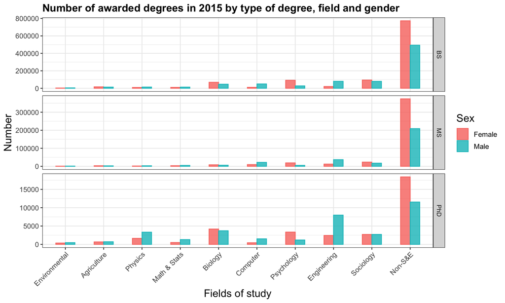

```r
# plot showing number of awarded degrees by gender (color) for the year 2015
w_df %>%
  filter(Year == 2015) %>%
  ggplot(aes(x = forcats::fct_reorder(Field, Number), y = Number, fill = Sex, colour = Sex)) +
  geom_bar(stat = "identity", position = "dodge", alpha = 0.8, width = 0.5) +
  facet_grid(Degree~., scales = "free_y") +
  theme_bw() +
  labs(x="Fields of study") +
  ggtitle("Number of awarded degrees in 2015 by type of degree, field and gender") +
  theme(plot.title = element_text(face="bold", size = 15)) +
  theme(legend.text = element_text(size = 10),
        legend.title = element_text(size = 15),
        axis.title = element_text(size = 15),
        axis.text.x = element_text(size = 10, angle = 45, hjust = 1),
        axis.text.y = element_text(size = 10))
```

In 2015, the number of awarded bachelor degrees is larger overall in comparison to master and PhD degrees. Gender proportions are mostly similar in different degree types for a given subfield. However, some striking exceptions in this plot are `Engineering` and `Physical Sciences`, for which the number of males is much higher at the PhD level, as well as `Psychology`, which has a higher number of women at the PhD level.

## 3.4 EDA bring all variables

In this last portion of the EDA, we ask you to provide evidence numerically and graphically: Do the number of degrees change by gender, field, and time?

### 3.4.1 Summary statistics by field, gender and time

First, we are providing a numeric summary of the percentage of female students per field type, degree type and year.

```r
# summarizing by field type, degree, time and sex
agg <- w_df %>%
  group_by(Field_type, Sex, Year, Degree) %>%
  summarise(total_number = sum(Number)) %>%
  group_by(Field_type, Year, Degree) %>%
  mutate(percent = (total_number / sum(total_number)) * 100) %>%
  filter(Sex == "Female") %>%
  group_by(Field_type, Year, Degree) %>%
  summarise("Percent female" = percent)


# preparing html table
kbl(agg) %>%
  kable_paper() %>%
    scroll_box(height = "300px", width = "50%")
```

| Field_type | Year | Degree | Percent female |
| --- | --- | --- | --- |
| Non-S&E fields | 2006 | BS | 61.1 |
| Non-S&E fields | 2006 | MS | 63.8 |
| Non-S&E fields | 2006 | PhD | 59.9 |
| Non-S&E fields | 2007 | BS | 60.8 |
| Non-S&E fields | 2007 | MS | 64.4 |
| Non-S&E fields | 2007 | PhD | 61.5 |
| Non-S&E fields | 2008 | BS | 60.6 |
| Non-S&E fields | 2008 | MS | 64.3 |
| Non-S&E fields | 2008 | PhD | 61.8 |
| Non-S&E fields | 2009 | BS | 60.4 |
| Non-S&E fields | 2009 | MS | 64.2 |
| Non-S&E fields | 2009 | PhD | 61.6 |
| Non-S&E fields | 2010 | BS | 60.4 |
| Non-S&E fields | 2010 | MS | 64.0 |
| Non-S&E fields | 2010 | PhD | 60.5 |
| Non-S&E fields | 2011 | BS | 60.6 |
| Non-S&E fields | 2011 | MS | 64.0 |
| Non-S&E fields | 2011 | PhD | 60.4 |
| Non-S&E fields | 2012 | BS | 60.7 |
| Non-S&E fields | 2012 | MS | 63.9 |
| Non-S&E fields | 2012 | PhD | 60.9 |
| Non-S&E fields | 2013 | BS | 60.7 |
| Non-S&E fields | 2013 | MS | 63.9 |
| Non-S&E fields | 2013 | PhD | 60.5 |
| Non-S&E fields | 2014 | BS | 60.8 |
| Non-S&E fields | 2014 | MS | 64.0 |
| Non-S&E fields | 2014 | PhD | 61.6 |
| Non-S&E fields | 2015 | BS | 61.0 |
| Non-S&E fields | 2015 | MS | 64.2 |
| Non-S&E fields | 2015 | PhD | 61.4 |
| Non-S&E fields | 2016 | BS | 61.2 |
| Non-S&E fields | 2016 | MS | 64.3 |
| Non-S&E fields | 2016 | PhD | 62.2 |
| Science fields | 2006 | BS | 50.3 |
| Science fields | 2006 | MS | 45.2 |
| Science fields | 2006 | PhD | 39.8 |
| Science fields | 2007 | BS | 50.2 |
| Science fields | 2007 | MS | 45.7 |
| Science fields | 2007 | PhD | 40.4 |
| Science fields | 2008 | BS | 50.3 |
| Science fields | 2008 | MS | 45.6 |
| Science fields | 2008 | PhD | 40.7 |
| Science fields | 2009 | BS | 50.4 |
| Science fields | 2009 | MS | 45.4 |
| Science fields | 2009 | PhD | 41.1 |
| Science fields | 2010 | BS | 50.3 |
| Science fields | 2010 | MS | 45.5 |
| Science fields | 2010 | PhD | 41.1 |
| Science fields | 2011 | BS | 50.3 |
| Science fields | 2011 | MS | 45.3 |
| Science fields | 2011 | PhD | 41.0 |
| Science fields | 2012 | BS | 50.5 |
| Science fields | 2012 | MS | 45.6 |
| Science fields | 2012 | PhD | 41.1 |
| Science fields | 2013 | BS | 50.3 |
| Science fields | 2013 | MS | 45.9 |
| Science fields | 2013 | PhD | 41.3 |
| Science fields | 2014 | BS | 50.0 |
| Science fields | 2014 | MS | 46.0 |
| Science fields | 2014 | PhD | 41.6 |
| Science fields | 2015 | BS | 49.7 |
| Science fields | 2015 | MS | 45.1 |
| Science fields | 2015 | PhD | 41.5 |
| Science fields | 2016 | BS | 49.7 |
| Science fields | 2016 | MS | 44.3 |
| Science fields | 2016 | PhD | 40.7 |

We can observe that overall, the percent of women in science fields tends to be more equal at the BS level in most fields, but decreases in MS and PhD levels.

Next, we are providing a numeric summary of the percentage of female students per subfield, degree type and year.

```r
# summarizing by field, degree, time and sex
agg <- w_df %>%
  group_by(Field, Sex, Year, Degree) %>%
  summarise(total_number = sum(Number)) %>%
  group_by(Field, Year, Degree) %>%
  mutate(percent = (total_number / sum(total_number)) * 100) %>%
  filter(Sex == "Female") %>%
  group_by(Field, Year, Degree) %>%
  summarise("Percent female" = percent)


# nicer html table
kbl(agg) %>%
  kable_paper() %>%
    scroll_box(height = "300px", width = "50%")
```

| Field | Year | Degree | Percent female |
| --- | --- | --- | --- |
| Agriculture | 2006 | BS | 51.5 |
| Agriculture | 2006 | MS | 52.5 |
| Agriculture | 2006 | PhD | 41.0 |
| Agriculture | 2007 | BS | 50.4 |
| Agriculture | 2007 | MS | 54.9 |
| Agriculture | 2007 | PhD | 41.0 |
| Agriculture | 2008 | BS | 51.2 |
| Agriculture | 2008 | MS | 54.6 |
| Agriculture | 2008 | PhD | 41.2 |
| Agriculture | 2009 | BS | 51.3 |
| Agriculture | 2009 | MS | 53.3 |
| Agriculture | 2009 | PhD | 44.3 |
| Agriculture | 2010 | BS | 52.5 |
| Agriculture | 2010 | MS | 52.2 |
| Agriculture | 2010 | PhD | 46.3 |
| Agriculture | 2011 | BS | 52.1 |
| Agriculture | 2011 | MS | 53.4 |
| Agriculture | 2011 | PhD | 46.6 |
| Agriculture | 2012 | BS | 53.6 |
| Agriculture | 2012 | MS | 54.0 |
| Agriculture | 2012 | PhD | 47.2 |
| Agriculture | 2013 | BS | 53.7 |
| Agriculture | 2013 | MS | 55.1 |
| Agriculture | 2013 | PhD | 46.8 |
| Agriculture | 2014 | BS | 53.9 |
| Agriculture | 2014 | MS | 55.7 |
| Agriculture | 2014 | PhD | 48.3 |
| Agriculture | 2015 | BS | 55.1 |
| Agriculture | 2015 | MS | 55.7 |
| Agriculture | 2015 | PhD | 48.2 |

[output cut: 300 more lines]

We can observe that the percent female tends to remain stable over time in any given field, and decreases somewhat at the PhD level.

Next, we are providing a summary of the difference in percent females per field and degree type between the year 2006 and 2006.

```r
# summarizing the percent change from 2006-2016 by field, degree and sex
agg <- w_df %>%
  group_by(Field, Sex, Year, Degree) %>%
  summarise(total_number = sum(Number)) %>%
  group_by(Field, Year, Degree) %>%
  mutate(percent = (total_number / sum(total_number)) * 100) %>%
  filter(Sex == "Female" & (Year == "2006" | Year == "2016")) %>%
  group_by(Field, Degree) %>%
  mutate(percent_change = percent - lag(percent)) %>%
  filter(Year == "2016") %>%
  group_by(Field, Degree) %>%
  summarise("2006-2016 percent change in females" = round(percent_change, 1))


# preparing html table
kbl(agg) %>%
  kable_paper() %>%
    scroll_box(height = "300px", width = "50%")
```

| Field | Degree | 2006-2016 percent change in females |
| --- | --- | --- |
| Agriculture | BS | 4.0 |
| Agriculture | MS | 4.4 |
| Agriculture | PhD | 5.8 |
| Biology | BS | -1.2 |
| Biology | MS | -0.9 |
| Biology | PhD | 3.5 |
| Computer | BS | -2.0 |
| Computer | MS | 3.8 |
| Computer | PhD | -1.6 |
| Engineering | BS | 1.4 |
| Engineering | MS | 1.8 |
| Engineering | PhD | 3.4 |
| Environmental | BS | -2.9 |
| Environmental | MS | -1.9 |
| Environmental | PhD | 4.6 |
| Math & Stats | BS | -2.5 |
| Math & Stats | MS | -1.1 |
| Math & Stats | PhD | -1.1 |
| Non-S&E | BS | 0.2 |
| Non-S&E | MS | 0.5 |
| Non-S&E | PhD | 2.3 |
| Physics | BS | -3.3 |
| Physics | MS | -2.2 |
| Physics | PhD | 1.6 |
| Psychology | BS | 0.2 |
| Psychology | MS | 0.5 |
| Psychology | PhD | 0.3 |
| Sociology | BS | 1.1 |
| Sociology | MS | 0.8 |
| Sociology | PhD | 2.8 |

We can observe that overall, the percent of females receiving a degree in various fields remains stable, with a maximum of 5.8% change in `Agricultural Sciences` at the PhD level (showing an increase of women at the PhD level over time in this subfield).

### 3.4.2 Plots by field, gender and time

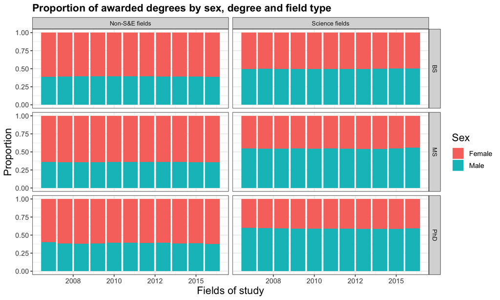

```r
# plot by field type, degree, time and sex
w_df %>% group_by(Field_type, Sex, Year, Degree) %>%
  summarise(total_number = sum(Number)) %>%
  ggplot(aes(x = Year, y = total_number, fill = Sex)) +
  geom_bar(stat = "identity", position = "fill") +
  facet_grid(Degree ~ Field_type, scales = "free_y") +
  theme_bw() +
  labs(x="Fields of study", y = "Proportion") +
  ggtitle("Proportion of awarded degrees by sex, degree and field type") +
  theme(plot.title = element_text(face="bold", size = 15)) +
  theme(legend.text = element_text(size = 10),
        legend.title = element_text(size = 15),
        axis.title = element_text(size = 15),
        axis.text.x = element_text(size = 10),
        axis.text.y = element_text(size = 10))
```

Overall, `Science fields` seem to have roughly 50% women, indicating a roughly equal representation of males and females when considering all science fields together. Of note, we observe a progressive increase in the proportion of males at the MS and PhD levels, compared to BS which has a roughly equal representation of both genders.

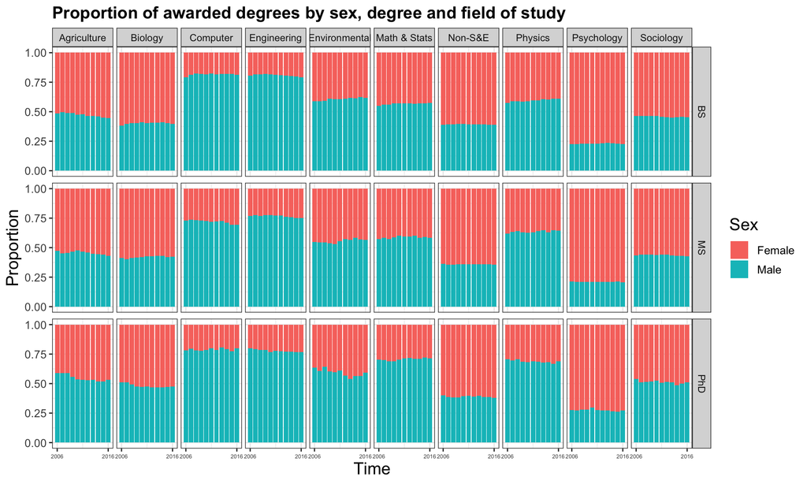

```r
# plot by subfield, degree, time and sex
w_df %>% group_by(Field, Sex, Year, Degree) %>%
  summarise(total_number = sum(Number)) %>%
  ggplot(aes(x = Year, y = total_number, fill = Sex)) +
  geom_bar(stat = "identity", position = "fill") +
  facet_grid(Degree ~ Field, scales = "free_x") +
  ggtitle("Proportion of awarded degrees by sex, degree and field of study") +
  theme_bw() +
  labs(x="Time", y = "Proportion") +
  theme(plot.title = element_text(face="bold", size = 15)) +
  theme(legend.text = element_text(size = 10),
        legend.title = element_text(size = 15),
        axis.title = element_text(size = 15),
        axis.text.x = element_text(size = 5),
        axis.text.y = element_text(size = 10)) +
  scale_x_continuous(breaks = seq(2006, 2016, 10)) +
  theme(panel.spacing.x = unit(1, "mm"))
```

These graphs again highlight that even though overall, `Science fields` seem to have roughly 50% women, this does not hold true when considering science subfields at a more granular level. Specifically, we note the markedly higher proportion of men in `Engineering`, `Computer Sciences`, `Physical Sciences`, `Mathematics and Statistics`, `Environmnental Sciences` and the higher proportion of women in `Psychology`, `Non-S&E` and `Biological Sciences`. Moreover, gender proportions tend to remain table across the years (2006-2016), regardless of field type (`Non-S&E` vs `Science fields`) or subfields.

## 3.5 Women in Data Science

Finally, is there evidence showing that women are underrepresented in data science? Data science is an interdisciplinary field of computer science, math, and statistics. You may include year and/or degree.

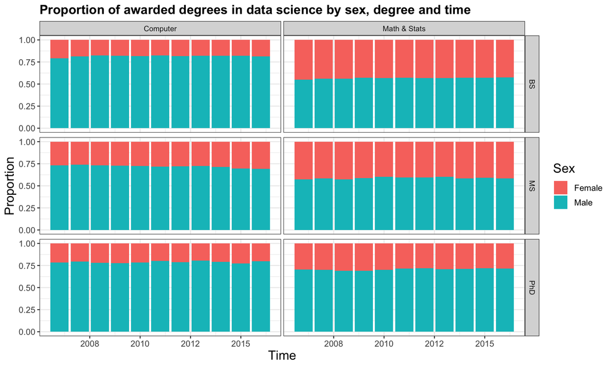

```r
# plot by degree, time and sex for data science fields only
w_df %>% group_by(Field, Sex, Year, Degree) %>%
  filter(Field %in% c("Computer", "Math & Stats")) %>%
  summarise(total_number = sum(Number)) %>%
  ggplot(aes(x = Year, y = total_number, fill = Sex)) +
  geom_bar(stat = "identity", position = "fill") +
  facet_grid(Degree ~ Field, scales = "free_x") +
  ggtitle("Proportion of awarded degrees in data science by sex, degree and time") +
  theme_bw() +
  labs(x="Time", y = "Proportion") +
  theme(plot.title = element_text(face="bold", size = 15)) +
  theme(legend.text = element_text(size = 10),
        legend.title = element_text(size = 15),
        axis.title = element_text(size = 15),
        axis.text.x = element_text(size = 10),
        axis.text.y = element_text(size = 10)) +
  theme(panel.spacing.x = unit(1, "mm"))
```

## 3.6 Final brief report

Summarize your findings focusing on answering the questions regarding if we see consistent patterns that more males pursue science-related fields. Any concerns with the data set? How could we improve on the study?

When considering all science fields together, the proportion of males and females engaging in science related fields appears similar and has remained balanced from 2006-2016, with a slight increase in the propotion of males at MS and PhD levels. However, when considering gender proportions in subfields of science, we notice a remarkable variation. Specifically, while a number of subfields appear balanced (`Agricultural sciences`, `Social Sciences`), certain subfields contain a strikingly larger proportion of women (`Psychology`, `Biological Sciences`) or men (`Computer Sciences`, `Engineering`, `Physical Sciences`, `Mathematics and Statistics`, `Environmnental Sciences`) respectively. Finally, these gender proportions remained stable across the considered 10 year period (2006-2016).

To further improve on the study, it would be interesting to investigate gender proportions among subfields within the `Non-S$E` category. Given that large discrepancies in gender proportions were found when studying science subfields even though the overall gender propotion seemed balanced, it is possible that gender proportions in subfields of `Non-S&E` also might vary a lot compared to the overall proportion reported in this dataset. It would also be interesting to collect this type of data in more recent years to determine whether the trends are now changing or still remain stable. Finally, another avenue to explore would be gender distributions across professions and type of function several years after graduation.

## 3.7 Appendix

To help out, we have included some R-codes here as references. You should make your own chunks filled with texts going through each items listed above. Make sure to hide the unnecessary outputs/code etc.

1. Clean data
2. A number of sample analyses

# 4 Case study 3: Major League Baseball

We would like to explore how payroll affects performance among Major League Baseball teams. The data is prepared in two formats record payroll, winning numbers/percentage by team from 1998 to 2014.

Here are the datasets:

-`MLPayData_Total.csv`: wide format -`baseball.csv`: long format

Feel free to use either dataset to address the problems.

## 4.1 EDA: Relationship between payroll changes and performance

Payroll may relate to performance among ML Baseball teams. One possible argument is that what affects this year’s performance is not this year’s payroll, but the amount that payroll increased from last year. Let us look into this through EDA.

Create increment in payroll

1. To describe the increment of payroll in each year there are several possible approaches. Take 2013 as an example:
   - option 1: diff: payroll_2013 - payroll_2012
   - option 2: log diff: log(payroll_2013) - log(payroll_2012)

Explain why the log difference is more appropriate in this setup.

2. Create a new variable `diff_log=log(payroll_2013) - log(payroll_2012)`. Hint: use `dplyr::lag()` function.
3. Create a long data table including: team, year, diff_log, win_pct

## 4.2 Exploratory questions

1. Which five teams had highest increase in their payroll between years 2010 and 2014, inclusive?
2. Between 2010 and 2014, inclusive, which team(s) “improved” the most? That is, had the biggest percentage gain in wins?

## 4.3 Do log increases in payroll imply better performance?

Is there evidence to support the hypothesis that higher increases in payroll on the log scale lead to increased performance?

Pick up a few statistics, accompanied with some data visualization, to support your answer.

## 4.4 Comparison

Which set of factors are better explaining performance? Yearly payroll or yearly increase in payroll? What criterion is being used?